# Generating SQL for SQLite using Ollama, ChromaDB

This notebook runs through the process of using the `vanna` Python package to generate SQL using AI (RAG + LLMs) including connecting to a database and training. If you're not ready to train on your own database, you can still try it using a sample SQLite database.

### Which LLM do you want to use?

- OpenAI via Vanna.AI (Recommended)

  Use Vanna.AI for free to generate your queries
- OpenAI

  Use OpenAI with your own API key
- Azure OpenAI

  If you have OpenAI models deployed on Azure
- Ollama

  Use Ollama locally for free. Requires additional setup.
- Mistral via Mistral API

  If you have a Mistral API key
- Other LLM

  If you have a different LLM model

### Where do you want to store the 'training' data?

- Vanna Hosted Vector DB (Recommended)

  Use Vanna.AIs hosted vector database (pgvector) for free. This is usable across machines with no additional setup.
- ChromaDB

  Use ChromaDBs open-source vector database for free locally. No additional setup is necessary -- all database files will be created and stored locally.
- Marqo

  Use Marqo locally for free. Requires additional setup. Or use their hosted option.
- Other VectorDB

  Use any other vector database. Requires additional setup.

## Setup

```python
from vanna.ollama import Ollama
from vanna.chromadb.chromadb_vector import ChromaDB_VectorStore
```

```python
class MyVanna(ChromaDB_VectorStore, Ollama):
    def __init__(self, config=None):
        ChromaDB_VectorStore.__init__(self, config=config)
        Ollama.__init__(self, config=config)

config = {
    'model': 'llama3.1'  # 'mistral' # "starcoder2"
}
vn = MyVanna(config=config)
```

### Which database do you want to query?

- Postgres
- Microsoft SQL Server
- DuckDB
- Snowflake
- BigQuery
- SQLite
- Other Database

  Use Vanna to generate queries for any SQL database

```python
import os.path
import re
from time import time
```

```python
# file_db = "./db/gpt3sql.sqlite"

file_db = "~/Downloads/chinook.sqlite"
file_db = os.path.abspath(os.path.expanduser(file_db))
vn.connect_to_sqlite(file_db)
```

```python
vn.run_sql_is_set
```

```
True
```

```python
def remove_collections(collection_name=None, ACCEPTED_TYPES = ["sql", "ddl", "documentation"]):
    if not collection_name:
        collections = ACCEPTED_TYPES
    elif isinstance(collection_name, str):
        collections = [collection_name]
    elif isinstance(collection_name, list):
        collections = collection_name
    else:
        print(f"\t{collection_name} is unknown: Skipped")
        return

    for c in collections:
        if not c in ACCEPTED_TYPES:
            print(f"\t{c} is unknown: Skipped")
            continue

        # print(f"vn.remove_collection('{c}')")
        vn.remove_collection(c)
```

```python
def strip_brackets(ddl):
    """
    This function removes square brackets from table and column names in a DDL script.

    Args:
        ddl (str): The DDL script containing square brackets.

    Returns:
        str: The DDL script with square brackets removed.
    """
    # Use regular expressions to match and replace square brackets
    pattern = r"\[([^\]]+)]"  # Match any character except ] within square brackets
    return re.sub(pattern, r"\1", ddl)
```

```python
if True:
    remove_collections()
```

## Training

You only need to train once. Do not train again unless you want to add more training data.

```python
# show training data
training_data = vn.get_training_data()
training_data
```

|  | id | question | content | training_data_type |
| --- | --- | --- | --- | --- |

```python
df_ddl = vn.run_sql("SELECT type, sql FROM sqlite_master WHERE sql is not null")
```

```python
df_ddl
```

|  | type | sql |
| --- | --- | --- |
| 0 | table | CREATE TABLE [Album]\n(\n [AlbumId] INTEGER... |
| 1 | table | CREATE TABLE [Artist]\n(\n [ArtistId] INTEG... |
| 2 | table | CREATE TABLE [Customer]\n(\n [CustomerId] I... |
| 3 | table | CREATE TABLE [Employee]\n(\n [EmployeeId] I... |
| 4 | table | CREATE TABLE [Genre]\n(\n [GenreId] INTEGER... |
| 5 | table | CREATE TABLE [Invoice]\n(\n [InvoiceId] INT... |
| 6 | table | CREATE TABLE [InvoiceLine]\n(\n [InvoiceLin... |
| 7 | table | CREATE TABLE [MediaType]\n(\n [MediaTypeId]... |
| 8 | table | CREATE TABLE [Playlist]\n(\n [PlaylistId] I... |
| 9 | table | CREATE TABLE [PlaylistTrack]\n(\n [Playlist... |
| 10 | table | CREATE TABLE [Track]\n(\n [TrackId] INTEGER... |
| 11 | index | CREATE INDEX [IFK_AlbumArtistId] ON [Album] ([... |
| 12 | index | CREATE INDEX [IFK_CustomerSupportRepId] ON [Cu... |
| 13 | index | CREATE INDEX [IFK_EmployeeReportsTo] ON [Emplo... |
| 14 | index | CREATE INDEX [IFK_InvoiceCustomerId] ON [Invoi... |
| 15 | index | CREATE INDEX [IFK_InvoiceLineInvoiceId] ON [In... |
| 16 | index | CREATE INDEX [IFK_InvoiceLineTrackId] ON [Invo... |
| 17 | index | CREATE INDEX [IFK_PlaylistTrackTrackId] ON [Pl... |
| 18 | index | CREATE INDEX [IFK_TrackAlbumId] ON [Track] ([A... |
| 19 | index | CREATE INDEX [IFK_TrackGenreId] ON [Track] ([G... |
| 20 | index | CREATE INDEX [IFK_TrackMediaTypeId] ON [Track]... |

```python
for ddl in df_ddl['sql'].to_list():
    ddl = strip_brackets(ddl)
    vn.train(ddl=ddl)
```

```
Adding ddl: CREATE TABLE Album
(
    AlbumId INTEGER  NOT NULL,
    Title NVARCHAR(160)  NOT NULL,
    ArtistId INTEGER  NOT NULL,
    CONSTRAINT PK_Album PRIMARY KEY  (AlbumId),
    FOREIGN KEY (ArtistId) REFERENCES Artist (ArtistId)
		ON DELETE NO ACTION ON UPDATE NO ACTION
)
Adding ddl: CREATE TABLE Artist
(
    ArtistId INTEGER  NOT NULL,
    Name NVARCHAR(120),
    CONSTRAINT PK_Artist PRIMARY KEY  (ArtistId)
)
Adding ddl: CREATE TABLE Customer
(
    CustomerId INTEGER  NOT NULL,
    FirstName NVARCHAR(40)  NOT NULL,
    LastName NVARCHAR(20)  NOT NULL,
    Company NVARCHAR(80),
    Address NVARCHAR(70),
    City NVARCHAR(40),
    State NVARCHAR(40),
    Country NVARCHAR(40),
    PostalCode NVARCHAR(10),
    Phone NVARCHAR(24),
    Fax NVARCHAR(24),
    Email NVARCHAR(60)  NOT NULL,
    SupportRepId INTEGER,
    CONSTRAINT PK_Customer PRIMARY KEY  (CustomerId),
    FOREIGN KEY (SupportRepId) REFERENCES Employee (EmployeeId)
		ON DELETE NO ACTION ON UPDATE NO ACTION
)
Adding ddl: CREATE TABLE Employee
(
    EmployeeId INTEGER  NOT NULL,
    LastName NVARCHAR(20)  NOT NULL,
    FirstName NVARCHAR(20)  NOT NULL,
    Title NVARCHAR(30),
```

[output cut: 85 more lines]

```
    FOREIGN KEY (GenreId) REFERENCES Genre (GenreId)
		ON DELETE NO ACTION ON UPDATE NO ACTION,
    FOREIGN KEY (MediaTypeId) REFERENCES MediaType (MediaTypeId)
		ON DELETE NO ACTION ON UPDATE NO ACTION
)
Adding ddl: CREATE INDEX IFK_AlbumArtistId ON Album (ArtistId)
Adding ddl: CREATE INDEX IFK_CustomerSupportRepId ON Customer (SupportRepId)
Adding ddl: CREATE INDEX IFK_EmployeeReportsTo ON Employee (ReportsTo)
Adding ddl: CREATE INDEX IFK_InvoiceCustomerId ON Invoice (CustomerId)
Adding ddl: CREATE INDEX IFK_InvoiceLineInvoiceId ON InvoiceLine (InvoiceId)
Adding ddl: CREATE INDEX IFK_InvoiceLineTrackId ON InvoiceLine (TrackId)
Adding ddl: CREATE INDEX IFK_PlaylistTrackTrackId ON PlaylistTrack (TrackId)
Adding ddl: CREATE INDEX IFK_TrackAlbumId ON Track (AlbumId)
Adding ddl: CREATE INDEX IFK_TrackGenreId ON Track (GenreId)
Adding ddl: CREATE INDEX IFK_TrackMediaTypeId ON Track (MediaTypeId)
```

## Asking the AI

Whenever you ask a new question, it will find the 10 most relevant pieces of training data and use it as part of the LLM prompt to generate the SQL.

```python
ts_start = time()
```

[output not shown]

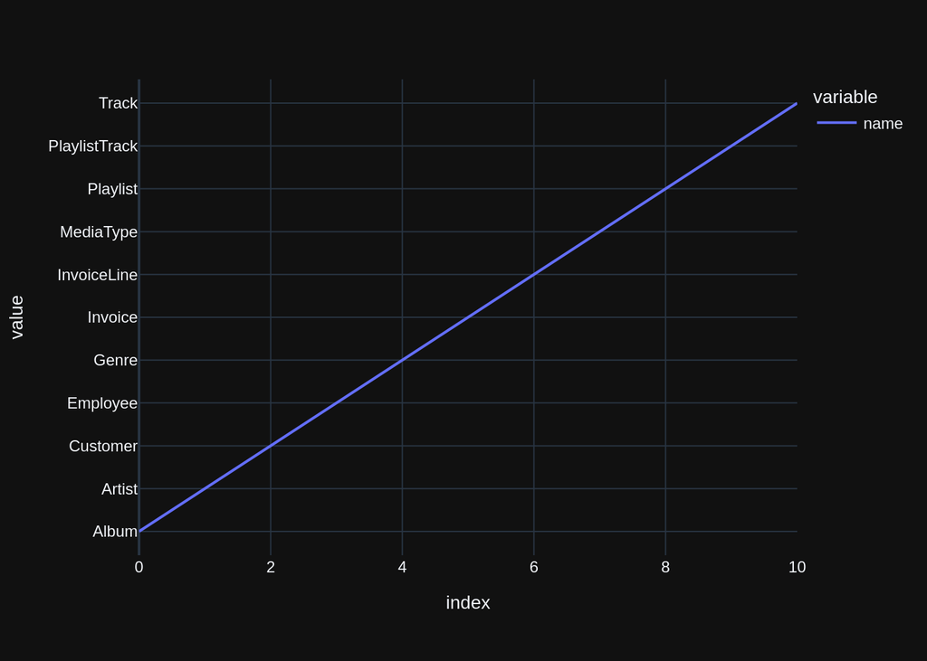

```
("SELECT name FROM sqlite_master WHERE type='table'",
              name
 0           Album
 1          Artist
 2        Customer
 3        Employee
 4           Genre
 5         Invoice
 6     InvoiceLine
 7       MediaType
 8        Playlist
 9   PlaylistTrack
 10          Track,
 Figure({
     'data': [{'hovertemplate': 'variable=name<br>index=%{x}<br>value=%{y}<extra></extra>',
               'legendgroup': 'name',
               'line': {'color': '#636efa', 'dash': 'solid'},
               'marker': {'symbol': 'circle'},
               'mode': 'lines',
               'name': 'name',
               'orientation': 'v',
               'showlegend': True,
               'type': 'scatter',
               'x': array([ 0,  1,  2,  3,  4,  5,  6,  7,  8,  9, 10]),
               'xaxis': 'x',
               'y': array(['Album', 'Artist', 'Customer', 'Employee', 'Genre', 'Invoice',
                           'InvoiceLine', 'MediaType', 'Playlist', 'PlaylistTrack', 'Track'],
                          dtype=object),
               'yaxis': 'y'}],
     'layout': {'legend': {'title': {'text': 'variable'}, 'tracegroupgap': 0},
                'margin': {'t': 60},
                'template': '...',
                'xaxis': {'anchor': 'y', 'domain': [0.0, 1.0], 'title': {'text': 'index'}},
                'yaxis': {'anchor': 'x', 'domain': [0.0, 1.0], 'title': {'text': 'value'}}}
 }))
```

```python
vn.ask(question="What are the table names in the database")
```

```python
vn.ask(question="Show me a list of tables in the SQLite database")
```

[output not shown]

```python
vn.ask(question="which tables store order information")
```

[output not shown]

[output cut: 32 more lines]

[output not shown]

[output not shown]

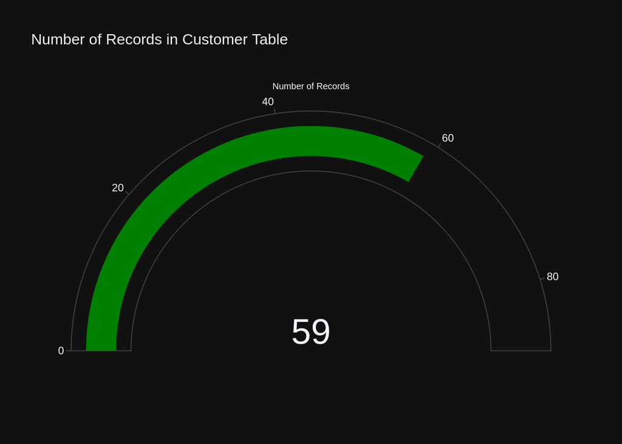

```
('SELECT COUNT(*) FROM customer',
    COUNT(*)
 0        59,
 Figure({
     'data': [{'mode': 'gauge+number',
               'number': {'font': {'size': 40}},
               'title': {'text': 'Number of Records'},
               'type': 'indicator',
               'value': 59}],
     'layout': {'template': '...', 'title': {'text': 'Number of Records in Customer Table'}}
 }))
```

```python
vn.ask(question="How many records are in table called customer")
```

```
Number of requested results 10 is greater than number of elements in index 1, updating n_results = 1
```

[output not shown]

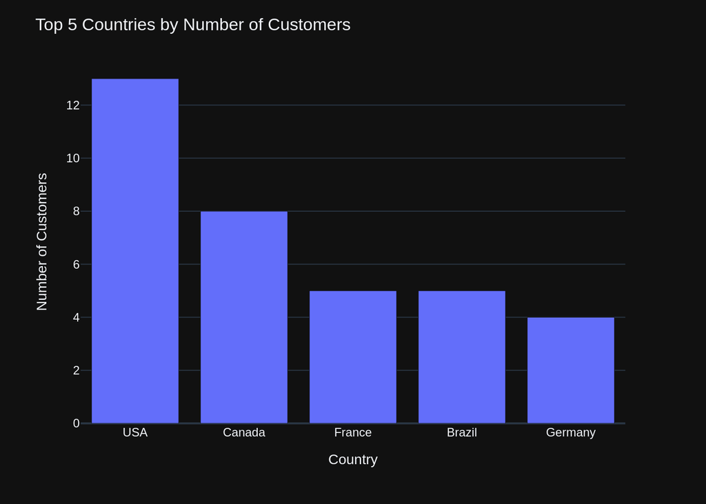

```
('SELECT Country, COUNT(CustomerId) AS NumberOfCustomers\nFROM Customer\nGROUP BY Country\nORDER BY NumberOfCustomers DESC\nLIMIT 5',
    Country  NumberOfCustomers
 0      USA                 13
 1   Canada                  8
 2   France                  5
 3   Brazil                  5
 4  Germany                  4,
 Figure({
     'data': [{'alignmentgroup': 'True',
               'hovertemplate': 'Country=%{x}<br>NumberOfCustomers=%{y}<extra></extra>',
               'legendgroup': '',
               'marker': {'color': '#636efa', 'pattern': {'shape': ''}},
               'name': '',
               'offsetgroup': '',
               'orientation': 'v',
               'showlegend': False,
               'textposition': 'auto',
               'type': 'bar',
               'x': array(['USA', 'Canada', 'France', 'Brazil', 'Germany'], dtype=object),
               'xaxis': 'x',
               'y': array([13,  8,  5,  5,  4]),
               'yaxis': 'y'}],
     'layout': {'barmode': 'relative',
                'legend': {'tracegroupgap': 0},
                'margin': {'t': 60},
                'template': '...',
                'title': {'text': 'Top 5 Countries by Number of Customers'},
                'xaxis': {'anchor': 'y', 'domain': [0.0, 1.0], 'title': {'text': 'Country'}},
                'yaxis': {'anchor': 'x', 'domain': [0.0, 1.0], 'title': {'text': 'Number of Customers'}}}
 }))
```

```python
vn.ask(question="what are the top 5 countries that customers come from?")
```

### More SQL questions

see `sample-sql-queries-sqlite-chinook.ipynb`

```
Number of requested results 10 is greater than number of elements in index 2, updating n_results = 2
```

[output not shown]

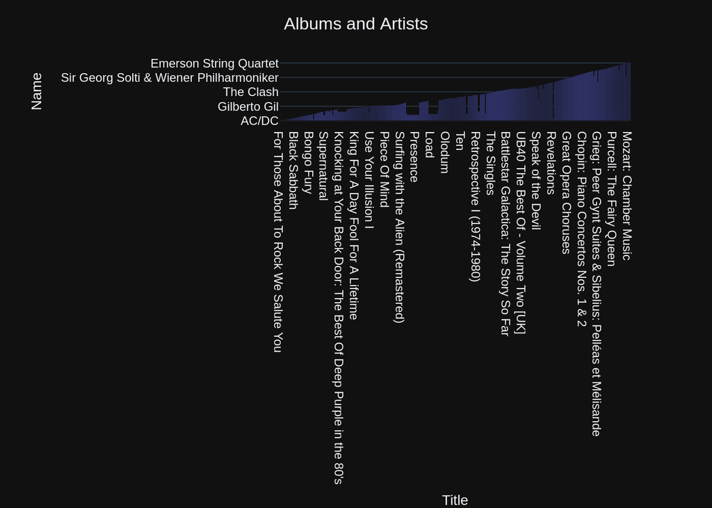

```
('SELECT A.Title, ART.Name \nFROM Album AS A \nJOIN Artist AS ART ON A.ArtistId = ART.ArtistId',
                                                  Title  \
 0                For Those About To Rock We Salute You
 1                                    Balls to the Wall
 2                                    Restless and Wild
 3                                    Let There Be Rock
 4                                             Big Ones
 ..                                                 ...
 342                             Respighi:Pines of Rome
 343  Schubert: The Late String Quartets & String Qu...
 344                                Monteverdi: L'Orfeo
 345                              Mozart: Chamber Music
 346  Koyaanisqatsi (Soundtrack from the Motion Pict...

                                                   Name
 0                                                AC/DC
 1                                               Accept
 2                                               Accept
 3                                                AC/DC
 4                                            Aerosmith
 ..                                                 ...
 342                                     Eugene Ormandy
 343                             Emerson String Quartet
 344  C. Monteverdi, Nigel Rogers - Chiaroscuro; Lon...
 345                                      Nash Ensemble
 346                              Philip Glass Ensemble

 [347 rows x 2 columns],
 Figure({
     'data': [{'alignmentgroup': 'True',
               'hovertemplate': 'Title=%{x}<br>Name=%{y}<extra></extra>',
               'legendgroup': '',
               'marker': {'color': '#636efa', 'pattern': {'shape': ''}},
               'name': '',
               'offsetgroup': '',
               'orientation': 'v',
               'showlegend': False,
               'textposition': 'auto',
               'type': 'bar',
               'x': array(['For Those About To Rock We Salute You', 'Balls to the Wall',
                           'Restless and Wild', ..., "Monteverdi: L'Orfeo",
                           'Mozart: Chamber Music',
                           'Koyaanisqatsi (Soundtrack from the Motion Picture)'], dtype=object),
               'xaxis': 'x',
               'y': array(['AC/DC', 'Accept', 'Accept', ...,
                           'C. Monteverdi, Nigel Rogers - Chiaroscuro; London Baroque; London Cornett & Sackbu',
                           'Nash Ensemble', 'Philip Glass Ensemble'], dtype=object),
               'yaxis': 'y'}],
     'layout': {'barmode': 'relative',
                'legend': {'tracegroupgap': 0},
                'margin': {'t': 60},
                'template': '...',
                'title': {'text': 'Albums and Artists', 'x': 0.5},
                'xaxis': {'anchor': 'y', 'domain': [0.0, 1.0], 'title': {'text': 'Title'}},
                'yaxis': {'anchor': 'x', 'domain': [0.0, 1.0], 'title': {'text': 'Name'}}}
 }))
```

```python
question = """
    List all albums and their corresponding artist names
"""

vn.ask(question=question)
```

```
Number of requested results 10 is greater than number of elements in index 3, updating n_results = 3
```

[output not shown]

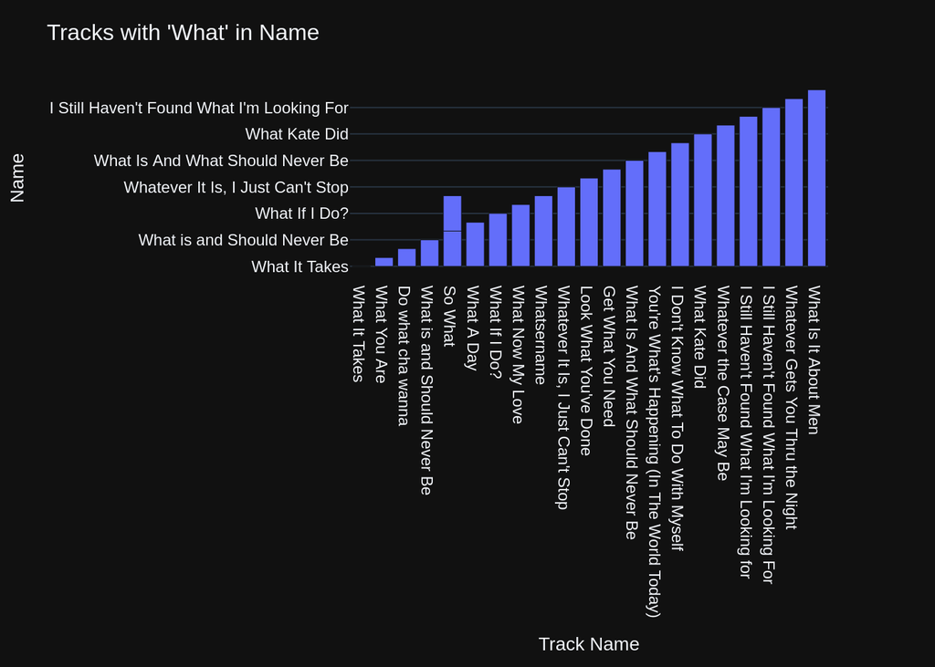

```
("SELECT Name \nFROM Track \nWHERE LOWER(Name) LIKE '%what%'",
                                             Name
 0                                  What It Takes
 1                                   What You Are
 2                              Do what cha wanna
 3                    What is and Should Never Be
 4                                        So What
 5                                     What A Day
 6                                  What If I Do?
 7                               What Now My Love
 8                                    Whatsername
 9              Whatever It Is, I Just Can't Stop
 10                         Look What You've Done
 11                             Get What You Need
 12              What Is And What Should Never Be
 13  You're What's Happening (In The World Today)
 14                                       So What
 15           I Don't Know What To Do With Myself
 16                                 What Kate Did
 17                      Whatever the Case May Be
 18    I Still Haven't Found What I'm Looking for
 19    I Still Haven't Found What I'm Looking For
 20              Whatever Gets You Thru the Night
 21                          What Is It About Men,
 Figure({
     'data': [{'alignmentgroup': 'True',
               'hovertemplate': 'Name=%{y}<extra></extra>',
               'legendgroup': '',
               'marker': {'color': '#636efa', 'pattern': {'shape': ''}},
               'name': '',
               'offsetgroup': '',
               'orientation': 'v',
               'showlegend': False,
               'textposition': 'auto',
               'type': 'bar',
               'x': array(['What It Takes', 'What You Are', 'Do what cha wanna',
                           'What is and Should Never Be', 'So What', 'What A Day', 'What If I Do?',
                           'What Now My Love', 'Whatsername', "Whatever It Is, I Just Can't Stop",
                           "Look What You've Done", 'Get What You Need',
                           'What Is And What Should Never Be',
```

[output cut: 14 more lines]

```
                           "I Don't Know What To Do With Myself", 'What Kate Did',
                           'Whatever the Case May Be',
                           "I Still Haven't Found What I'm Looking for",
                           "I Still Haven't Found What I'm Looking For",
                           'Whatever Gets You Thru the Night', 'What Is It About Men'],
                          dtype=object),
               'yaxis': 'y'}],
     'layout': {'barmode': 'relative',
                'legend': {'tracegroupgap': 0},
                'margin': {'t': 60},
                'template': '...',
                'title': {'text': "Tracks with 'What' in Name"},
                'xaxis': {'anchor': 'y', 'domain': [0.0, 1.0], 'title': {'text': 'Track Name'}},
                'yaxis': {'anchor': 'x', 'domain': [0.0, 1.0], 'title': {'text': 'Name'}}}
 }))
```

```python
question = """
    Find all tracks with a name containing "What" (case-insensitive)
"""

vn.ask(question=question)
```

```
Number of requested results 10 is greater than number of elements in index 4, updating n_results = 4
```

[output not shown]

[output cut: 30 more lines]

````
52          53              7
53          54              7
54          55              7
55          56              7
56          57              7
57          58              7
58          59              6
Info: Ollama parameters:
model=llama3.1:latest,
options={},
keep_alive=None
Info: Prompt Content:
[{"role": "system", "content": "The following is a pandas DataFrame that contains the results of the query that answers the question the user asked: '  \n    Get the total number of invoices for each customer\n'\n\nThe DataFrame was produced using this query: SELECT C.CustomerId, COUNT(I.InvoiceId) …
Info: Ollama Response:
{'model': 'llama3.1:latest', 'created_at': '2024-07-24T05:21:03.609493422Z', 'message': {'role': 'assistant', 'content': "```python\nimport plotly.express as px\n\nif df['TotalInvoices'].nunique() == 1:\n    fig = px.indicator(value=df['TotalInvoices'].iloc[0],\n                        title='Total …
````

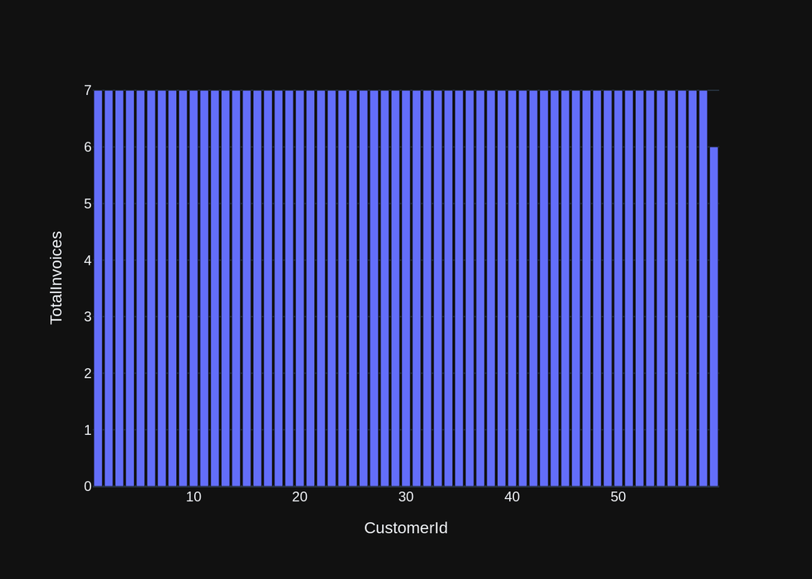

```
('SELECT C.CustomerId, COUNT(I.InvoiceId) AS TotalInvoices \nFROM Customer C \nJOIN Invoice I ON C.CustomerId = I.CustomerId \nGROUP BY C.CustomerId',
     CustomerId  TotalInvoices
 0            1              7
 1            2              7
 2            3              7
 3            4              7
 4            5              7
 5            6              7
 6            7              7
 7            8              7
 8            9              7
 9           10              7
 10          11              7
 11          12              7
 12          13              7
```

[output cut: 73 more lines]

```python
question = """
    Get the total number of invoices for each customer
"""

vn.ask(question=question)
```

```
Number of requested results 10 is greater than number of elements in index 5, updating n_results = 5
```

[output not shown]

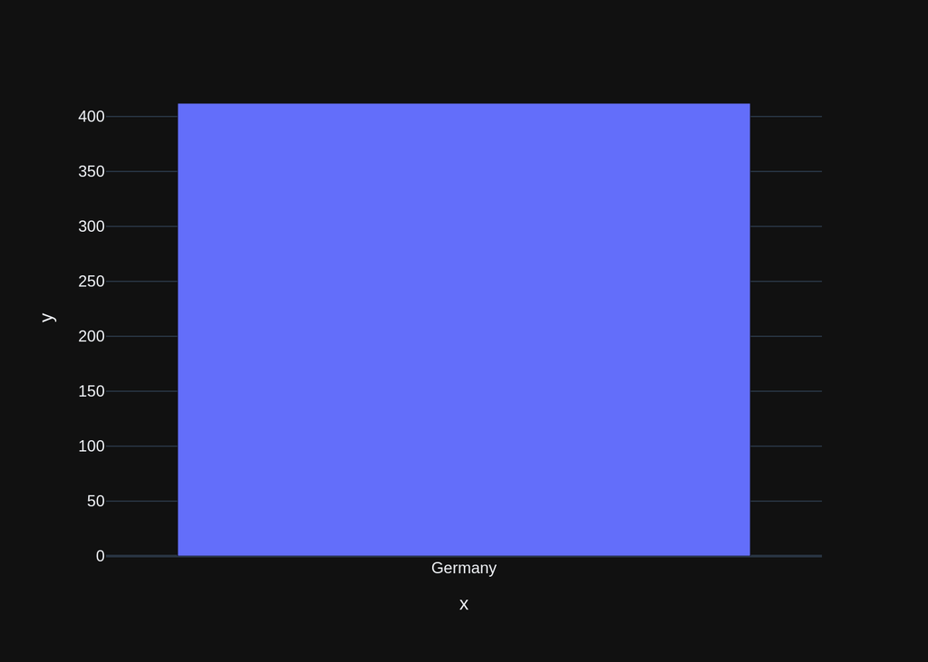

```
('SELECT COUNT(DISTINCT InvoiceId), BillingCountry\nFROM Invoice',
    COUNT(DISTINCT InvoiceId) BillingCountry
 0                        412        Germany,
 Figure({
     'data': [{'alignmentgroup': 'True',
               'hovertemplate': 'x=%{x}<br>y=%{y}<extra></extra>',
               'legendgroup': '',
               'marker': {'color': '#636efa', 'pattern': {'shape': ''}},
               'name': '',
               'offsetgroup': '',
               'orientation': 'v',
               'showlegend': False,
               'textposition': 'auto',
               'type': 'bar',
               'x': array(['Germany'], dtype=object),
               'xaxis': 'x',
               'y': array([412]),
               'yaxis': 'y'}],
     'layout': {'barmode': 'relative',
                'legend': {'tracegroupgap': 0},
                'margin': {'t': 60},
                'template': '...',
                'xaxis': {'anchor': 'y', 'domain': [0.0, 1.0], 'title': {'text': 'x'}},
                'yaxis': {'anchor': 'x', 'domain': [0.0, 1.0], 'title': {'text': 'y'}}}
 }))
```

```python
question = """
    Find the total number of invoices per country:
"""

vn.ask(question=question)
```

```
Number of requested results 10 is greater than number of elements in index 6, updating n_results = 6
```

[output not shown]

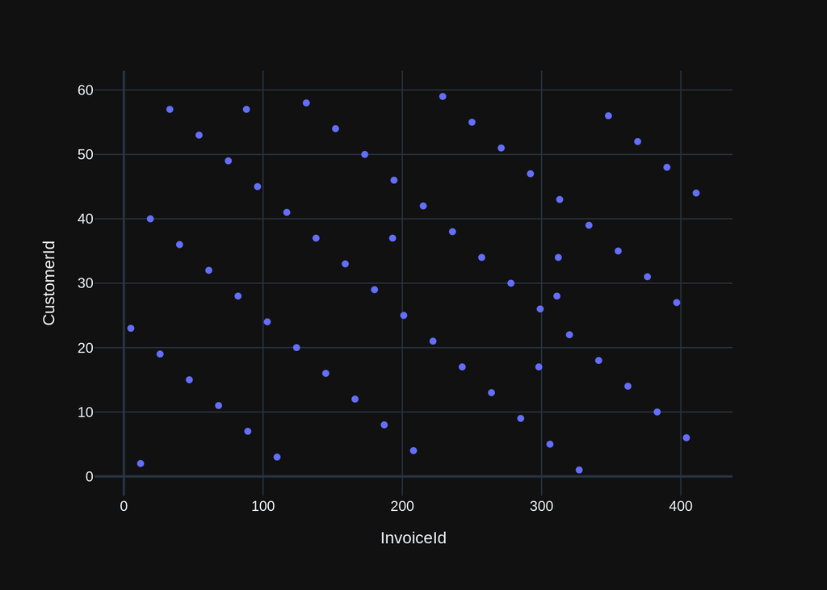

```
('SELECT * FROM Invoice WHERE Total > 10',
     InvoiceId  CustomerId          InvoiceDate             BillingAddress  \
 0           5          23  2009-01-11 00:00:00            69 Salem Street
 1          12           2  2009-02-11 00:00:00    Theodor-Heuss-Straße 34
 2          19          40  2009-03-14 00:00:00             8, Rue Hanovre
 3          26          19  2009-04-14 00:00:00            1 Infinite Loop
 4          33          57  2009-05-15 00:00:00            Calle Lira, 198
 ..        ...         ...                  ...                        ...
 59        383          10  2013-08-12 00:00:00  Rua Dr. Falcão Filho, 155
 60        390          48  2013-09-12 00:00:00      Lijnbaansgracht 120bg
 61        397          27  2013-10-13 00:00:00            1033 N Park Ave
 62        404           6  2013-11-13 00:00:00              Rilská 3174/6
 63        411          44  2013-12-14 00:00:00            Porthaninkatu 9

    BillingCity BillingState  BillingCountry BillingPostalCode  Total
 0       Boston           MA             USA              2113  13.86
 1    Stuttgart         None         Germany             70174  13.86
 2        Paris         None          France             75002  13.86
 3    Cupertino           CA             USA             95014  13.86
 4     Santiago         None           Chile              None  13.86
 ..         ...          ...             ...               ...    ...
 59   São Paulo           SP          Brazil         01007-010  13.86
 60   Amsterdam           VV     Netherlands              1016  13.86
 61      Tucson           AZ             USA             85719  13.86
 62      Prague         None  Czech Republic             14300  25.86
 63    Helsinki         None         Finland             00530  13.86

 [64 rows x 9 columns],
 Figure({
     'data': [{'hovertemplate': 'InvoiceId=%{x}<br>CustomerId=%{y}<extra></extra>',
               'legendgroup': '',
               'marker': {'color': '#636efa', 'symbol': 'circle'},
               'mode': 'markers',
               'name': '',
               'orientation': 'v',
               'showlegend': False,
               'type': 'scatter',
               'x': array([  5,  12,  19,  26,  33,  40,  47,  54,  61,  68,  75,  82,  88,  89,
                            96, 103, 110, 117, 124, 131, 138, 145, 152, 159, 166, 173, 180, 187,
                           193, 194, 201, 208, 215, 222, 229, 236, 243, 250, 257, 264, 271, 278,
                           285, 292, 298, 299, 306, 311, 312, 313, 320, 327, 334, 341, 348, 355,
                           362, 369, 376, 383, 390, 397, 404, 411]),
               'xaxis': 'x',
               'y': array([23,  2, 40, 19, 57, 36, 15, 53, 32, 11, 49, 28, 57,  7, 45, 24,  3, 41,
                           20, 58, 37, 16, 54, 33, 12, 50, 29,  8, 37, 46, 25,  4, 42, 21, 59, 38,
                           17, 55, 34, 13, 51, 30,  9, 47, 17, 26,  5, 28, 34, 43, 22,  1, 39, 18,
                           56, 35, 14, 52, 31, 10, 48, 27,  6, 44]),
               'yaxis': 'y'}],
     'layout': {'legend': {'tracegroupgap': 0},
                'margin': {'t': 60},
                'template': '...',
                'xaxis': {'anchor': 'y', 'domain': [0.0, 1.0], 'title': {'text': 'InvoiceId'}},
                'yaxis': {'anchor': 'x', 'domain': [0.0, 1.0], 'title': {'text': 'CustomerId'}}}
 }))
```

```python
question = """
    List all invoices with a total exceeding $10:
"""

vn.ask(question=question)
```

```
Number of requested results 10 is greater than number of elements in index 7, updating n_results = 7
```

[output not shown]

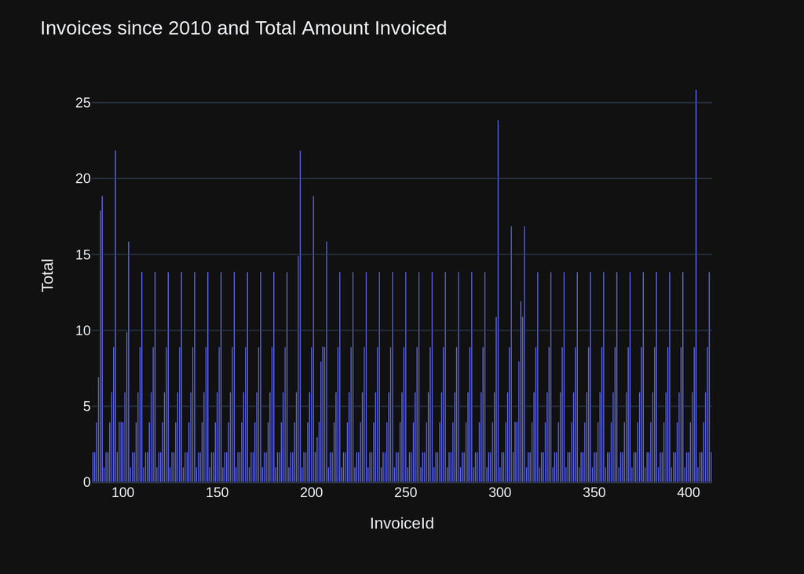

```
("SELECT DISTINCT InvoiceId, Total\nFROM Invoice\nWHERE InvoiceDate >= '2010-01-01'",
      InvoiceId  Total
 0           84   1.98
 1           85   1.98
 2           86   3.96
 3           87   6.94
 4           88  17.91
 ..         ...    ...
 324        408   3.96
 325        409   5.94
 326        410   8.91
 327        411  13.86
 328        412   1.99

 [329 rows x 2 columns],
 Figure({
     'data': [{'alignmentgroup': 'True',
               'hovertemplate': 'InvoiceId=%{x}<br>Total=%{y}<extra></extra>',
               'legendgroup': '',
               'marker': {'color': '#636efa', 'pattern': {'shape': ''}},
               'name': '',
               'offsetgroup': '',
               'orientation': 'v',
               'showlegend': False,
               'textposition': 'auto',
               'type': 'bar',
               'x': array([ 84,  85,  86, ..., 410, 411, 412]),
               'xaxis': 'x',
               'y': array([ 1.98,  1.98,  3.96, ...,  8.91, 13.86,  1.99]),
               'yaxis': 'y'}],
     'layout': {'barmode': 'relative',
                'legend': {'tracegroupgap': 0},
                'margin': {'t': 60},
                'template': '...',
                'title': {'text': 'Invoices since 2010 and Total Amount Invoiced'},
                'xaxis': {'anchor': 'y', 'domain': [0.0, 1.0], 'title': {'text': 'InvoiceId'}},
                'yaxis': {'anchor': 'x', 'domain': [0.0, 1.0], 'title': {'text': 'Total'}}}
 }))
```

```python
question = """
    Find all invoices since 2010 and the total amount invoiced:
"""

vn.ask(question=question)
```

```
Number of requested results 10 is greater than number of elements in index 8, updating n_results = 8
```

[output not shown]

[figure not shown]

```
("SELECT E.FirstName + ' ' + E.LastName AS EmployeeName,\n       COALESCE(R.FirstName + ' ' + R.LastName, '--') AS ManagerName\nFROM Employee E\nLEFT JOIN Employee R ON E.ReportsTo = R.EmployeeId",
    EmployeeName ManagerName
 0             0          --
 1             0           0
 2             0           0
 3             0           0
 4             0           0
 5             0           0
 6             0           0
 7             0           0,
 Figure({
     'data': [{'alignmentgroup': 'True',
               'hovertemplate': 'EmployeeName=%{x}<br>ManagerName=%{y}<extra></extra>',
               'legendgroup': '',
               'marker': {'color': '#636efa', 'pattern': {'shape': ''}},
               'name': '',
               'offsetgroup': '',
               'orientation': 'h',
               'showlegend': False,
               'textposition': 'auto',
               'type': 'bar',
               'x': array([0, 0, 0, 0, 0, 0, 0, 0]),
               'xaxis': 'x',
               'y': array(['--', 0, 0, 0, 0, 0, 0, 0], dtype=object),
               'yaxis': 'y'}],
     'layout': {'barmode': 'group',
                'legend': {'tracegroupgap': 0},
                'margin': {'t': 60},
                'template': '...',
                'title': {'text': 'Employees and their Managers'},
                'xaxis': {'anchor': 'y', 'domain': [0.0, 1.0], 'title': {'text': 'EmployeeName'}},
                'yaxis': {'anchor': 'x', 'domain': [0.0, 1.0], 'title': {'text': 'ManagerName'}}}
 }))
```

```python
question = """
    List all employees and their reporting manager's name (if any):
"""

vn.ask(question=question)
```

[output not shown]

[output not shown]

[output cut: 68 more lines]

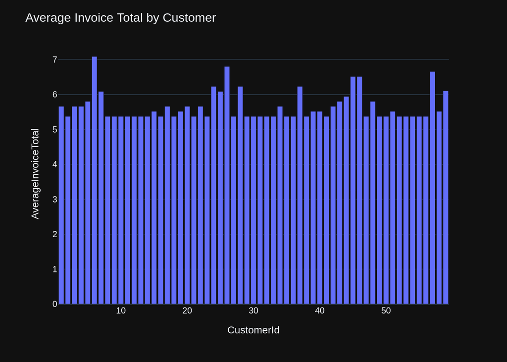

```
('SELECT CustomerId, AVG(Total) AS AverageInvoiceTotal \nFROM Invoice \nGROUP BY CustomerId',
     CustomerId  AverageInvoiceTotal
 0            1             5.660000
 1            2             5.374286
 2            3             5.660000
 3            4             5.660000
 4            5             5.802857
 5            6             7.088571
 6            7             6.088571
 7            8             5.374286
 8            9             5.374286
 9           10             5.374286
 10          11             5.374286
 11          12             5.374286
 12          13             5.374286
 13          14             5.374286
 14          15             5.517143
 15          16             5.374286
 16          17             5.660000
 17          18             5.374286
 18          19             5.517143
 19          20             5.660000
 20          21             5.374286
 21          22             5.660000
 22          23             5.374286
 23          24             6.231429
 24          25             6.088571
 25          26             6.802857
 26          27             5.374286
 27          28             6.231429
 28          29             5.374286
 29          30             5.374286
 30          31             5.374286
 31          32             5.374286
 32          33             5.374286
 33          34             5.660000
 34          35             5.374286
 35          36             5.374286
 36          37             6.231429
 37          38             5.374286
```

[output cut: 41 more lines]

```
                           6.08857143, 6.80285714, 5.37428571, 6.23142857, 5.37428571, 5.37428571,
                           5.37428571, 5.37428571, 5.37428571, 5.66      , 5.37428571, 5.37428571,
                           6.23142857, 5.37428571, 5.51714286, 5.51714286, 5.37428571, 5.66      ,
                           5.80285714, 5.94571429, 6.51714286, 6.51714286, 5.37428571, 5.80285714,
                           5.37428571, 5.37428571, 5.51714286, 5.37428571, 5.37428571, 5.37428571,
                           5.37428571, 5.37428571, 6.66      , 5.51714286, 6.10666667]),
               'yaxis': 'y'}],
     'layout': {'barmode': 'relative',
                'legend': {'tracegroupgap': 0},
                'margin': {'t': 60},
                'template': '...',
                'title': {'text': 'Average Invoice Total by Customer'},
                'xaxis': {'anchor': 'y', 'domain': [0.0, 1.0], 'title': {'text': 'CustomerId'}},
                'yaxis': {'anchor': 'x', 'domain': [0.0, 1.0], 'title': {'text': 'AverageInvoiceTotal'}}}
 }))
```

```python
question = """
    Get the average invoice total for each customer:
"""

vn.ask(question=question)
```

[output not shown]

[figure not shown]

```
('SELECT Track.Name, UnitPrice \nFROM Track \nORDER BY UnitPrice DESC \nLIMIT 5',
                                      Name  UnitPrice
 0  Battlestar Galactica: The Story So Far       1.99
 1                  Occupation / Precipice       1.99
 2                           Exodus, Pt. 1       1.99
 3                           Exodus, Pt. 2       1.99
 4                           Collaborators       1.99,
 Figure({
     'data': [{'alignmentgroup': 'True',
               'hovertemplate': 'Name=%{x}<br>UnitPrice=%{y}<extra></extra>',
               'legendgroup': '',
               'marker': {'color': '#636efa', 'pattern': {'shape': ''}},
               'name': '',
               'offsetgroup': '',
               'orientation': 'h',
               'showlegend': False,
               'textposition': 'auto',
               'type': 'bar',
               'x': array(['Battlestar Galactica: The Story So Far', 'Occupation / Precipice',
                           'Exodus, Pt. 1', 'Exodus, Pt. 2', 'Collaborators'], dtype=object),
               'xaxis': 'x',
               'y': array([1.99, 1.99, 1.99, 1.99, 1.99]),
               'yaxis': 'y'}],
     'layout': {'barmode': 'relative',
                'legend': {'tracegroupgap': 0},
                'template': '...',
                'title': {'text': 'Top 5 Most Expensive Tracks'},
                'xaxis': {'anchor': 'y', 'domain': [0.0, 1.0], 'title': {'text': 'Name'}},
                'yaxis': {'anchor': 'x', 'domain': [0.0, 1.0], 'title': {'text': 'UnitPrice'}}}
 }))
```

```python
question = """
    Find the top 5 most expensive tracks (based on unit price):
"""

vn.ask(question=question)
```

````
SQL Prompt: [{'role': 'system', 'content': "You are a SQLite expert. Please help to generate a SQL query to answer the question. Your response should ONLY be based on the given context and follow the response guidelines and format instructions. \n===Tables \nCREATE TABLE Track\n(\n    TrackId INTEGE…
Info: Ollama parameters:
model=llama3.1:latest,
options={},
keep_alive=None
Info: Prompt Content:
[{"role": "system", "content": "You are a SQLite expert. Please help to generate a SQL query to answer the question. Your response should ONLY be based on the given context and follow the response guidelines and format instructions. \n===Tables \nCREATE TABLE Track\n(\n    TrackId INTEGER  NOT NULL,…
Info: Ollama Response:
{'model': 'llama3.1:latest', 'created_at': '2024-07-24T05:30:43.311118262Z', 'message': {'role': 'assistant', 'content': 'SELECT G.Name, COUNT(T.TrackId) AS NumberOfTracks \nFROM Genre G \nJOIN Track T ON G.GenreId = T.GenreId \nGROUP BY G.Name'}, 'done_reason': 'stop', 'done': True, 'total_duration…
LLM Response: SELECT G.Name, COUNT(T.TrackId) AS NumberOfTracks
FROM Genre G
JOIN Track T ON G.GenreId = T.GenreId
GROUP BY G.Name
SELECT G.Name, COUNT(T.TrackId) AS NumberOfTracks
FROM Genre G
JOIN Track T ON G.GenreId = T.GenreId
GROUP BY G.Name
                  Name  NumberOfTracks
0          Alternative              40
1   Alternative & Punk             332
2                Blues              81
3           Bossa Nova              15
4            Classical              74
5               Comedy              17
6                Drama              64
7       Easy Listening              24
8    Electronica/Dance              30
9          Heavy Metal              28
10         Hip Hop/Rap              35
11                Jazz             130
12               Latin             579
13               Metal             374
14               Opera               1
15                 Pop              48
16            R&B/Soul              61
17              Reggae              58
18                Rock            1297
19       Rock And Roll              12
20    Sci Fi & Fantasy              26
21     Science Fiction              13
22          Soundtrack              43
23            TV Shows              93
24               World              28
Info: Ollama parameters:
model=llama3.1:latest,
options={},
keep_alive=None
Info: Prompt Content:
[{"role": "system", "content": "The following is a pandas DataFrame that contains the results of the query that answers the question the user asked: '  \n    List all genres and the number of tracks in each genre:\n'\n\nThe DataFrame was produced using this query: SELECT G.Name, COUNT(T.TrackId) AS …
Info: Ollama Response:
{'model': 'llama3.1:latest', 'created_at': '2024-07-24T05:31:04.528996061Z', 'message': {'role': 'assistant', 'content': "```python\nimport plotly.express as px\n\nfig = px.bar(df, x='Name', y='NumberOfTracks', title='Number of Tracks by Genre')\nfig.show()\n\n# if there's only one row in the datafr…
````

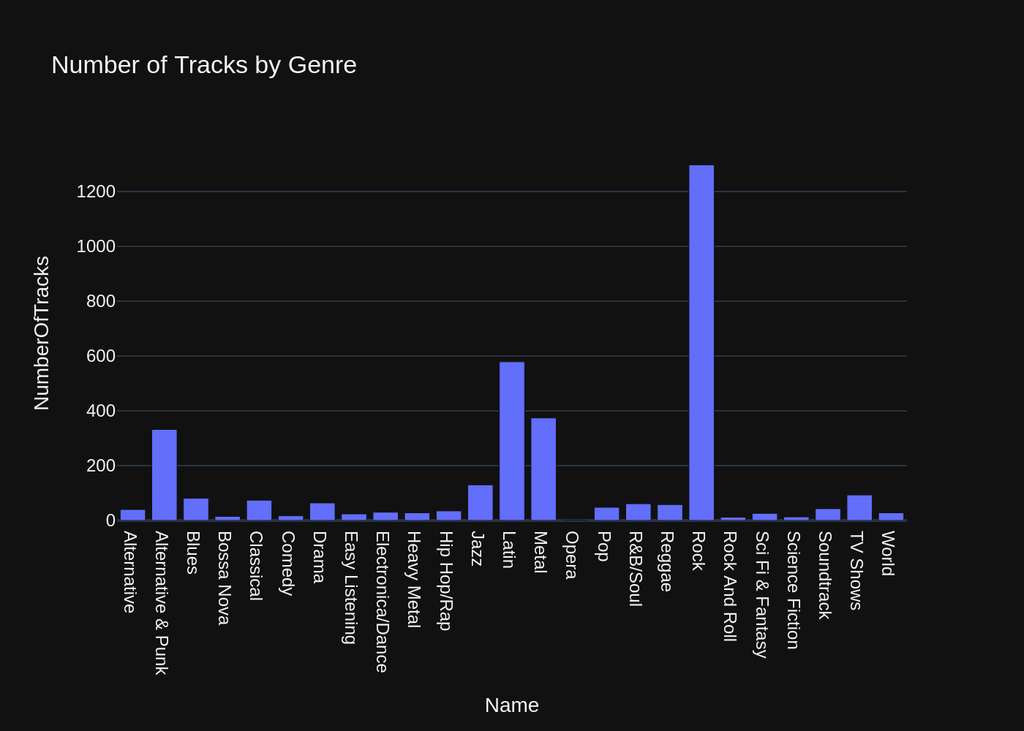

```
('SELECT G.Name, COUNT(T.TrackId) AS NumberOfTracks \nFROM Genre G \nJOIN Track T ON G.GenreId = T.GenreId \nGROUP BY G.Name',
                   Name  NumberOfTracks
 0          Alternative              40
 1   Alternative & Punk             332
 2                Blues              81
 3           Bossa Nova              15
 4            Classical              74
 5               Comedy              17
 6                Drama              64
 7       Easy Listening              24
 8    Electronica/Dance              30
 9          Heavy Metal              28
 10         Hip Hop/Rap              35
 11                Jazz             130
 12               Latin             579
 13               Metal             374
 14               Opera               1
 15                 Pop              48
 16            R&B/Soul              61
 17              Reggae              58
 18                Rock            1297
 19       Rock And Roll              12
 20    Sci Fi & Fantasy              26
 21     Science Fiction              13
 22          Soundtrack              43
 23            TV Shows              93
 24               World              28,
 Figure({
     'data': [{'alignmentgroup': 'True',
               'hovertemplate': 'Name=%{x}<br>NumberOfTracks=%{y}<extra></extra>',
               'legendgroup': '',
               'marker': {'color': '#636efa', 'pattern': {'shape': ''}},
               'name': '',
               'offsetgroup': '',
               'orientation': 'v',
               'showlegend': False,
               'textposition': 'auto',
               'type': 'bar',
               'x': array(['Alternative', 'Alternative & Punk', 'Blues', 'Bossa Nova', 'Classical',
                           'Comedy', 'Drama', 'Easy Listening', 'Electronica/Dance', 'Heavy Metal',
                           'Hip Hop/Rap', 'Jazz', 'Latin', 'Metal', 'Opera', 'Pop', 'R&B/Soul',
                           'Reggae', 'Rock', 'Rock And Roll', 'Sci Fi & Fantasy',
                           'Science Fiction', 'Soundtrack', 'TV Shows', 'World'], dtype=object),
               'xaxis': 'x',
               'y': array([  40,  332,   81,   15,   74,   17,   64,   24,   30,   28,   35,  130,
                            579,  374,    1,   48,   61,   58, 1297,   12,   26,   13,   43,   93,
                             28]),
               'yaxis': 'y'}],
     'layout': {'barmode': 'relative',
                'legend': {'tracegroupgap': 0},
                'template': '...',
                'title': {'text': 'Number of Tracks by Genre'},
                'xaxis': {'anchor': 'y', 'domain': [0.0, 1.0], 'title': {'text': 'Name'}},
                'yaxis': {'anchor': 'x', 'domain': [0.0, 1.0], 'title': {'text': 'NumberOfTracks'}}}
 }))
```

```python
question = """
    List all genres and the number of tracks in each genre:
"""

vn.ask(question=question)
```

````
SQL Prompt: [{'role': 'system', 'content': "You are a SQLite expert. Please help to generate a SQL query to answer the question. Your response should ONLY be based on the given context and follow the response guidelines and format instructions. \n===Tables \nCREATE INDEX IFK_TrackGenreId ON Track (G…
Info: Ollama parameters:
model=llama3.1:latest,
options={},
keep_alive=None
Info: Prompt Content:
[{"role": "system", "content": "You are a SQLite expert. Please help to generate a SQL query to answer the question. Your response should ONLY be based on the given context and follow the response guidelines and format instructions. \n===Tables \nCREATE INDEX IFK_TrackGenreId ON Track (GenreId)\n\nC…
Info: Ollama Response:
{'model': 'llama3.1:latest', 'created_at': '2024-07-24T05:32:05.889069108Z', 'message': {'role': 'assistant', 'content': 'SELECT Name FROM Genre WHERE GenreId NOT IN ( SELECT GenreId FROM Track )'}, 'done_reason': 'stop', 'done': True, 'total_duration': 61222033383, 'load_duration': 14744015, 'promp…
LLM Response: SELECT Name FROM Genre WHERE GenreId NOT IN ( SELECT GenreId FROM Track )
SELECT Name FROM Genre WHERE GenreId NOT IN ( SELECT GenreId FROM Track )
Empty DataFrame
Columns: [Name]
Index: []
Info: Ollama parameters:
model=llama3.1:latest,
options={},
keep_alive=None
Info: Prompt Content:
[{"role": "system", "content": "The following is a pandas DataFrame that contains the results of the query that answers the question the user asked: '  \n    Get all genres that do not have any tracks associated with them:\n'\n\nThe DataFrame was produced using this query: SELECT Name FROM Genre WHE…
Info: Ollama Response:
{'model': 'llama3.1:latest', 'created_at': '2024-07-24T05:32:31.764372979Z', 'message': {'role': 'assistant', 'content': "```python\nimport plotly.graph_objects as go\n\nif len(df) == 1:\n    fig = go.Figure(data=[go.Indicator(\n        title='Genres without tracks',\n        value=df['Name'].values…
````

[figure not shown]

```
('SELECT Name FROM Genre WHERE GenreId NOT IN ( SELECT GenreId FROM Track )',
 Empty DataFrame
 Columns: [Name]
 Index: [],
 Figure({
     'data': [{'type': 'bar', 'x': array([], dtype=object), 'y': []}],
     'layout': {'template': '...',
                'title': {'text': 'Genres without tracks'},
                'xaxis': {'title': {'text': 'Genre Name'}},
                'yaxis': {'title': {'text': ''}}}
 }))
```

```python
question = """
    Get all genres that do not have any tracks associated with them:
"""

vn.ask(question=question)
```

```python
question = """
    List all customers who have not placed any orders:
"""

vn.ask(question=question)
```

````
SQL Prompt: [{'role': 'system', 'content': "You are a SQLite expert. Please help to generate a SQL query to answer the question. Your response should ONLY be based on the given context and follow the response guidelines and format instructions. \n===Tables \nCREATE TABLE Customer\n(\n    CustomerId …
Info: Ollama parameters:
model=llama3.1:latest,
options={},
keep_alive=None
Info: Prompt Content:
[{"role": "system", "content": "You are a SQLite expert. Please help to generate a SQL query to answer the question. Your response should ONLY be based on the given context and follow the response guidelines and format instructions. \n===Tables \nCREATE TABLE Customer\n(\n    CustomerId INTEGER  NOT…
Info: Ollama Response:
{'model': 'llama3.1:latest', 'created_at': '2024-07-24T05:33:06.616938595Z', 'message': {'role': 'assistant', 'content': 'SELECT CustomerId FROM Customer EXCEPT SELECT CustomerId FROM Invoice'}, 'done_reason': 'stop', 'done': True, 'total_duration': 34758994127, 'load_duration': 15369501, 'prompt_ev…
LLM Response: SELECT CustomerId FROM Customer EXCEPT SELECT CustomerId FROM Invoice
SELECT CustomerId FROM Customer EXCEPT SELECT CustomerId FROM Invoice
Empty DataFrame
Columns: [CustomerId]
Index: []
Info: Ollama parameters:
model=llama3.1:latest,
options={},
keep_alive=None
Info: Prompt Content:
[{"role": "system", "content": "The following is a pandas DataFrame that contains the results of the query that answers the question the user asked: '  \n    List all customers who have not placed any orders:\n'\n\nThe DataFrame was produced using this query: SELECT CustomerId FROM Customer EXCEPT S…
Info: Ollama Response:
{'model': 'llama3.1:latest', 'created_at': '2024-07-24T05:33:32.036563314Z', 'message': {'role': 'assistant', 'content': '```python\nimport plotly.express as px\n\nfig = px.bar(df, x=\'CustomerId\', y=0, title=\'Customers without orders\')\nfig.show()\n\n# or if there is only one value\nif len(df) =…
````

```
('SELECT CustomerId FROM Customer EXCEPT SELECT CustomerId FROM Invoice',
 Empty DataFrame
 Columns: [CustomerId]
 Index: [],
 Figure({
     'data': [{'domain': {'x': [0.0, 1.0], 'y': [0.0, 1.0]},
               'hovertemplate': 'CustomerId=%{label}<extra></extra>',
               'labels': array([], dtype=object),
               'legendgroup': '',
               'name': '',
               'showlegend': True,
               'type': 'pie'}],
     'layout': {'legend': {'tracegroupgap': 0}, 'margin': {'t': 60}, 'template': '...'}
 }))
```

```python
question = """
    Get the top 10 most popular artists (based on the number of tracks):
"""

vn.ask(question=question)
```

```
SQL Prompt: [{'role': 'system', 'content': "You are a SQLite expert. Please help to generate a SQL query to answer the question. Your response should ONLY be based on the given context and follow the response guidelines and format instructions. \n===Tables \nCREATE TABLE Track\n(\n    TrackId INTEGE…
Info: Ollama parameters:
model=llama3.1:latest,
options={},
keep_alive=None
Info: Prompt Content:
[{"role": "system", "content": "You are a SQLite expert. Please help to generate a SQL query to answer the question. Your response should ONLY be based on the given context and follow the response guidelines and format instructions. \n===Tables \nCREATE TABLE Track\n(\n    TrackId INTEGER  NOT NULL,…
Info: Ollama Response:
{'model': 'llama3.1:latest', 'created_at': '2024-07-24T05:34:40.94504808Z', 'message': {'role': 'assistant', 'content': 'SELECT T.ArtistName, COUNT(T.TrackId) AS NumberOfTracks \nFROM (\n  SELECT A.Name AS ArtistName, T.Trackid FROM Track AS T \n  JOIN Album AS A ON T.AlbumId = A.AlbumId\n) AS T \nG…
LLM Response: SELECT T.ArtistName, COUNT(T.TrackId) AS NumberOfTracks
FROM (
  SELECT A.Name AS ArtistName, T.Trackid FROM Track AS T
  JOIN Album AS A ON T.AlbumId = A.AlbumId
) AS T
GROUP BY T.ArtistName
ORDER BY NumberOfTracks DESC
LIMIT 10
SELECT T.ArtistName, COUNT(T.TrackId) AS NumberOfTracks
FROM (
  SELECT A.Name AS ArtistName, T.Trackid FROM Track AS T
  JOIN Album AS A ON T.AlbumId = A.AlbumId
) AS T
GROUP BY T.ArtistName
ORDER BY NumberOfTracks DESC
LIMIT 10
Couldn't run sql:  Execution failed on sql 'SELECT T.ArtistName, COUNT(T.TrackId) AS NumberOfTracks
FROM (
  SELECT A.Name AS ArtistName, T.Trackid FROM Track AS T
  JOIN Album AS A ON T.AlbumId = A.AlbumId
) AS T
GROUP BY T.ArtistName
ORDER BY NumberOfTracks DESC
LIMIT 10': no such column: A.Name
```

````
SQL Prompt: [{'role': 'system', 'content': "You are a SQLite expert. Please help to generate a SQL query to answer the question. Your response should ONLY be based on the given context and follow the response guidelines and format instructions. \n===Tables \nCREATE TABLE Customer\n(\n    CustomerId …
Info: Ollama parameters:
model=llama3.1:latest,
options={},
keep_alive=None
Info: Prompt Content:
[{"role": "system", "content": "You are a SQLite expert. Please help to generate a SQL query to answer the question. Your response should ONLY be based on the given context and follow the response guidelines and format instructions. \n===Tables \nCREATE TABLE Customer\n(\n    CustomerId INTEGER  NOT…
Info: Ollama Response:
{'model': 'llama3.1:latest', 'created_at': '2024-07-24T05:35:50.396058561Z', 'message': {'role': 'assistant', 'content': "SELECT Country, Email FROM Customer WHERE Country = 'Canada'"}, 'done_reason': 'stop', 'done': True, 'total_duration': 69389926066, 'load_duration': 21248783, 'prompt_eval_count'…
LLM Response: SELECT Country, Email FROM Customer WHERE Country = 'Canada'
SELECT Country, Email FROM Customer WHERE Country = 'Canada'
  Country                   Email
0  Canada     ftremblay@gmail.com
1  Canada      mphilips12@shaw.ca
2  Canada     jenniferp@rogers.ca
3  Canada        robbrown@shaw.ca
4  Canada     edfrancis@yachoo.ca
5  Canada    marthasilk@gmail.com
6  Canada  aaronmitchell@yahoo.ca
7  Canada  ellie.sullivan@shaw.ca
Info: Ollama parameters:
model=llama3.1:latest,
options={},
keep_alive=None
Info: Prompt Content:
[{"role": "system", "content": "The following is a pandas DataFrame that contains the results of the query that answers the question the user asked: '  \n     List all customers from Canada and their email addresses:\n'\n\nThe DataFrame was produced using this query: SELECT Country, Email FROM Custo…
Info: Ollama Response:
{'model': 'llama3.1:latest', 'created_at': '2024-07-24T05:36:14.772692241Z', 'message': {'role': 'assistant', 'content': "```python\nimport plotly.express as px\n\nfig = px.bar(df, x='Country', y='Email')\nfig.update_layout(title='Customers from Canada and their email addresses',\n                  …
````

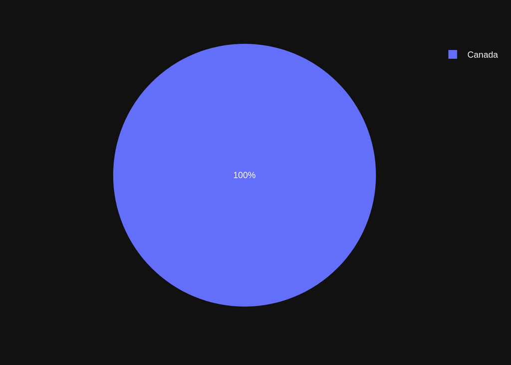

```
("SELECT Country, Email FROM Customer WHERE Country = 'Canada'",
   Country                   Email
 0  Canada     ftremblay@gmail.com
 1  Canada      mphilips12@shaw.ca
 2  Canada     jenniferp@rogers.ca
 3  Canada        robbrown@shaw.ca
 4  Canada     edfrancis@yachoo.ca
 5  Canada    marthasilk@gmail.com
 6  Canada  aaronmitchell@yahoo.ca
 7  Canada  ellie.sullivan@shaw.ca,
 Figure({
     'data': [{'domain': {'x': [0.0, 1.0], 'y': [0.0, 1.0]},
               'hovertemplate': 'Country=%{label}<extra></extra>',
               'labels': array(['Canada', 'Canada', 'Canada', 'Canada', 'Canada', 'Canada', 'Canada',
                                'Canada'], dtype=object),
               'legendgroup': '',
               'name': '',
               'showlegend': True,
               'type': 'pie'}],
     'layout': {'legend': {'tracegroupgap': 0}, 'margin': {'t': 60}, 'template': '...'}
 }))
```

```python
question = """
     List all customers from Canada and their email addresses:
"""

vn.ask(question=question)
```

````
SQL Prompt: [{'role': 'system', 'content': "You are a SQLite expert. Please help to generate a SQL query to answer the question. Your response should ONLY be based on the given context and follow the response guidelines and format instructions. \n===Tables \nCREATE INDEX IFK_InvoiceCustomerId ON Inv…
Info: Ollama parameters:
model=llama3.1:latest,
options={},
keep_alive=None
Info: Prompt Content:
[{"role": "system", "content": "You are a SQLite expert. Please help to generate a SQL query to answer the question. Your response should ONLY be based on the given context and follow the response guidelines and format instructions. \n===Tables \nCREATE INDEX IFK_InvoiceCustomerId ON Invoice (Custom…
Info: Ollama Response:
{'model': 'llama3.1:latest', 'created_at': '2024-07-24T05:37:30.295896527Z', 'message': {'role': 'assistant', 'content': 'SELECT C.Email FROM Customer C\nJOIN Invoice I ON C.CustomerId = I.CustomerId\nGROUP BY C.CustomerId, C.FirstName, C.LastName, C.Email\nORDER BY COUNT(I.InvoiceId) DESC\nLIMIT 1'…
LLM Response: SELECT C.Email FROM Customer C
JOIN Invoice I ON C.CustomerId = I.CustomerId
GROUP BY C.CustomerId, C.FirstName, C.LastName, C.Email
ORDER BY COUNT(I.InvoiceId) DESC
LIMIT 1
SELECT C.Email FROM Customer C
JOIN Invoice I ON C.CustomerId = I.CustomerId
GROUP BY C.CustomerId, C.FirstName, C.LastName, C.Email
ORDER BY COUNT(I.InvoiceId) DESC
LIMIT 1
                  Email
0  luisg@embraer.com.br
Info: Ollama parameters:
model=llama3.1:latest,
options={},
keep_alive=None
Info: Prompt Content:
[{"role": "system", "content": "The following is a pandas DataFrame that contains the results of the query that answers the question the user asked: '  \n     Find the customer with the most invoices \n'\n\nThe DataFrame was produced using this query: SELECT C.Email FROM Customer C\nJOIN Invoice I O…
Info: Ollama Response:
{'model': 'llama3.1:latest', 'created_at': '2024-07-24T05:37:52.550621712Z', 'message': {'role': 'assistant', 'content': '```python\nimport plotly.express as px\n\nif len(df) == 1:\n    fig = px.bar(x=df[\'Email\'], y=1)\nelse:\n    fig = px.bar(df, x=\'Email\', y=\'value\')\n\nfig.update_layout(\n …
````

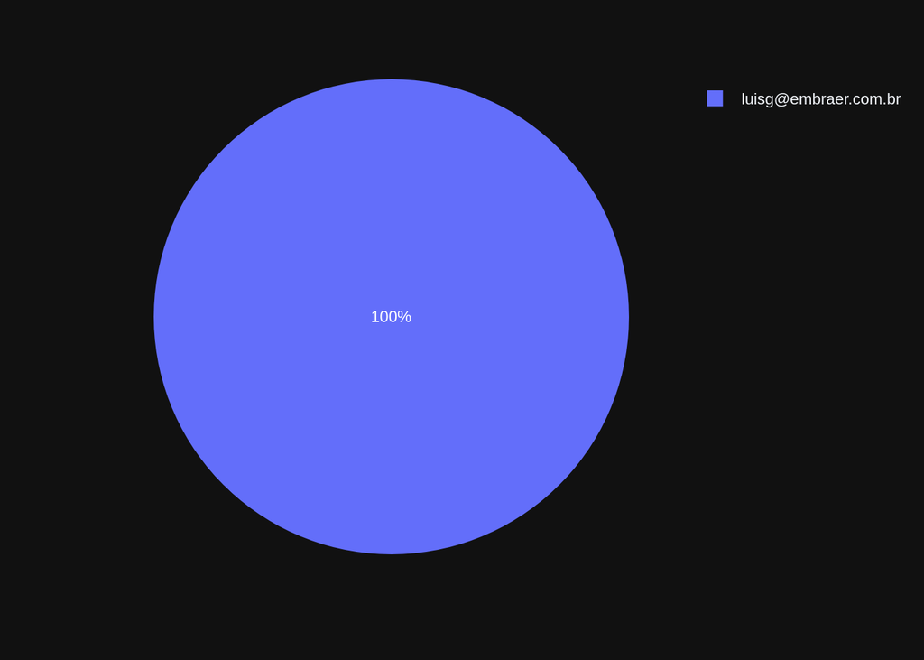

```
('SELECT C.Email FROM Customer C\nJOIN Invoice I ON C.CustomerId = I.CustomerId\nGROUP BY C.CustomerId, C.FirstName, C.LastName, C.Email\nORDER BY COUNT(I.InvoiceId) DESC\nLIMIT 1',
                   Email
 0  luisg@embraer.com.br,
 Figure({
     'data': [{'domain': {'x': [0.0, 1.0], 'y': [0.0, 1.0]},
               'hovertemplate': 'Email=%{label}<extra></extra>',
               'labels': array(['luisg@embraer.com.br'], dtype=object),
               'legendgroup': '',
               'name': '',
               'showlegend': True,
               'type': 'pie'}],
     'layout': {'legend': {'tracegroupgap': 0}, 'margin': {'t': 60}, 'template': '...'}
 }))
```

```python
question = """
     Find the customer with the most invoices
"""

vn.ask(question=question)
```

### Advanced SQL questions

```python
question = """
     Find the customer who bought the most albums in total quantity (across all invoices):
"""

vn.ask(question=question)
```

```
SQL Prompt: [{'role': 'system', 'content': "You are a SQLite expert. Please help to generate a SQL query to answer the question. Your response should ONLY be based on the given context and follow the response guidelines and format instructions. \n===Tables \nCREATE TABLE Track\n(\n    TrackId INTEGE…
Info: Ollama parameters:
model=llama3.1:latest,
options={},
keep_alive=None
Info: Prompt Content:
[{"role": "system", "content": "You are a SQLite expert. Please help to generate a SQL query to answer the question. Your response should ONLY be based on the given context and follow the response guidelines and format instructions. \n===Tables \nCREATE TABLE Track\n(\n    TrackId INTEGER  NOT NULL,…
Info: Ollama Response:
{'model': 'llama3.1:latest', 'created_at': '2024-07-24T05:39:13.399568541Z', 'message': {'role': 'assistant', 'content': "SELECT C.CustomerId, SUM(IL.Quantity) AS TotalAlbumsPurchased \nFROM Customer C \nJOIN Invoice I ON C.CustomerId = I.CustomerId \nJOIN InvoiceLine IL ON I.InvoiceId = IL.InvoiceI…
LLM Response: SELECT C.CustomerId, SUM(IL.Quantity) AS TotalAlbumsPurchased
FROM Customer C
JOIN Invoice I ON C.CustomerId = I.CustomerId
JOIN InvoiceLine IL ON I.InvoiceId = IL.InvoiceId
WHERE IL.TrackId IN ( SELECT TrackId FROM Track WHERE Genre = 'Album' )
GROUP BY C.CustomerId
ORDER BY TotalAlbumsPurchased DESC LIMIT 1
SELECT C.CustomerId, SUM(IL.Quantity) AS TotalAlbumsPurchased
FROM Customer C
JOIN Invoice I ON C.CustomerId = I.CustomerId
JOIN InvoiceLine IL ON I.InvoiceId = IL.InvoiceId
WHERE IL.TrackId IN ( SELECT TrackId FROM Track WHERE Genre = 'Album' )
GROUP BY C.CustomerId
ORDER BY TotalAlbumsPurchased DESC LIMIT 1
Couldn't run sql:  Execution failed on sql 'SELECT C.CustomerId, SUM(IL.Quantity) AS TotalAlbumsPurchased
FROM Customer C
JOIN Invoice I ON C.CustomerId = I.CustomerId
JOIN InvoiceLine IL ON I.InvoiceId = IL.InvoiceId
WHERE IL.TrackId IN ( SELECT TrackId FROM Track WHERE Genre = 'Album' )
GROUP BY C.CustomerId
ORDER BY TotalAlbumsPurchased DESC LIMIT 1': no such column: Genre
```

```python
question = """
     Find the top 5 customer who bought the most albums in total quantity (across all invoices):
"""

vn.ask(question=question)
```

```
SQL Prompt: [{'role': 'system', 'content': "You are a SQLite expert. Please help to generate a SQL query to answer the question. Your response should ONLY be based on the given context and follow the response guidelines and format instructions. \n===Tables \nCREATE TABLE Track\n(\n    TrackId INTEGE…
Info: Ollama parameters:
model=llama3.1:latest,
options={},
keep_alive=None
Info: Prompt Content:
[{"role": "system", "content": "You are a SQLite expert. Please help to generate a SQL query to answer the question. Your response should ONLY be based on the given context and follow the response guidelines and format instructions. \n===Tables \nCREATE TABLE Track\n(\n    TrackId INTEGER  NOT NULL,…
Info: Ollama Response:
{'model': 'llama3.1:latest', 'created_at': '2024-07-24T05:40:29.571530281Z', 'message': {'role': 'assistant', 'content': "SELECT C.CustomerId, SUM(Quantity) AS TotalAlbums \nFROM Customer C \nJOIN InvoiceLine I ON C.CustomerId = I.CustomerId \nWHERE Track.Name LIKE 'Album%' \nGROUP BY C.CustomerId \…
LLM Response: SELECT C.CustomerId, SUM(Quantity) AS TotalAlbums
FROM Customer C
JOIN InvoiceLine I ON C.CustomerId = I.CustomerId
WHERE Track.Name LIKE 'Album%'
GROUP BY C.CustomerId
ORDER BY TotalAlbums DESC
LIMIT 5
SELECT C.CustomerId, SUM(Quantity) AS TotalAlbums
FROM Customer C
JOIN InvoiceLine I ON C.CustomerId = I.CustomerId
WHERE Track.Name LIKE 'Album%'
GROUP BY C.CustomerId
ORDER BY TotalAlbums DESC
LIMIT 5
Couldn't run sql:  Execution failed on sql 'SELECT C.CustomerId, SUM(Quantity) AS TotalAlbums
FROM Customer C
JOIN InvoiceLine I ON C.CustomerId = I.CustomerId
WHERE Track.Name LIKE 'Album%'
GROUP BY C.CustomerId
ORDER BY TotalAlbums DESC
LIMIT 5': no such column: Track.Name
```

````
SQL Prompt: [{'role': 'system', 'content': "You are a SQLite expert. Please help to generate a SQL query to answer the question. Your response should ONLY be based on the given context and follow the response guidelines and format instructions. \n===Tables \nCREATE TABLE Track\n(\n    TrackId INTEGE…
Info: Ollama parameters:
model=llama3.1:latest,
options={},
keep_alive=None
Info: Prompt Content:
[{"role": "system", "content": "You are a SQLite expert. Please help to generate a SQL query to answer the question. Your response should ONLY be based on the given context and follow the response guidelines and format instructions. \n===Tables \nCREATE TABLE Track\n(\n    TrackId INTEGER  NOT NULL,…
Info: Ollama Response:
{'model': 'llama3.1:latest', 'created_at': '2024-07-24T11:34:34.442335943Z', 'message': {'role': 'assistant', 'content': 'SELECT C.CustomerId, SUM(Quantity) AS TotalAlbums \nFROM Customer C \nJOIN Invoice I ON C.CustomerId = I.CustomerId \nJOIN InvoiceLine IL ON I.InvoiceId = IL.InvoiceId \nJOIN Tra…
LLM Response: SELECT C.CustomerId, SUM(Quantity) AS TotalAlbums
FROM Customer C
JOIN Invoice I ON C.CustomerId = I.CustomerId
JOIN InvoiceLine IL ON I.InvoiceId = IL.InvoiceId
JOIN Track T ON IL.TrackId = T.Trackid
WHERE T.AlbumId IS NOT NULL
GROUP BY C.CustomerId
ORDER BY TotalAlbums DESC LIMIT 5
SELECT C.CustomerId, SUM(Quantity) AS TotalAlbums
FROM Customer C
JOIN Invoice I ON C.CustomerId = I.CustomerId
JOIN InvoiceLine IL ON I.InvoiceId = IL.InvoiceId
JOIN Track T ON IL.TrackId = T.Trackid
WHERE T.AlbumId IS NOT NULL
GROUP BY C.CustomerId
ORDER BY TotalAlbums DESC LIMIT 5
   CustomerId  TotalAlbums
0          58           38
1          57           38
2          56           38
3          55           38
4          54           38
Info: Ollama parameters:
model=llama3.1:latest,
options={},
keep_alive=None
Info: Prompt Content:
[{"role": "system", "content": "The following is a pandas DataFrame that contains the results of the query that answers the question the user asked: '  \nHint: album quantity is found in invoiceLine,           \nFind the top 5 customers who bought the most albums in total quantity (across all invoic…
Info: Ollama Response:
{'model': 'llama3.1:latest', 'created_at': '2024-07-24T11:35:02.06488707Z', 'message': {'role': 'assistant', 'content': "```python\nimport plotly.express as px\n\nif len(df) == 1:\n    fig = px.bar(x=df['CustomerId'], y=df['TotalAlbums'])\nelse:\n    fig = px.bar(df, x='CustomerID', y='TotalAlbums')…
````

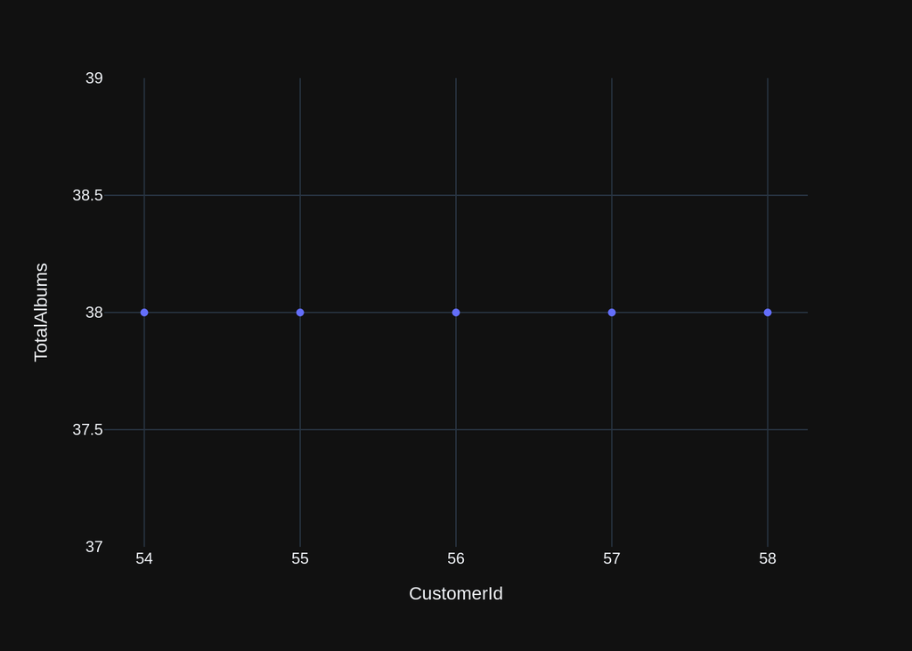

```
('SELECT C.CustomerId, SUM(Quantity) AS TotalAlbums \nFROM Customer C \nJOIN Invoice I ON C.CustomerId = I.CustomerId \nJOIN InvoiceLine IL ON I.InvoiceId = IL.InvoiceId \nJOIN Track T ON IL.TrackId = T.Trackid \nWHERE T.AlbumId IS NOT NULL \nGROUP BY C.CustomerId \nORDER BY TotalAlbums DESC LIMIT 5…
    CustomerId  TotalAlbums
 0          58           38
 1          57           38
 2          56           38
 3          55           38
 4          54           38,
 Figure({
     'data': [{'hovertemplate': 'CustomerId=%{x}<br>TotalAlbums=%{y}<extra></extra>',
               'legendgroup': '',
               'marker': {'color': '#636efa', 'symbol': 'circle'},
               'mode': 'markers',
               'name': '',
               'orientation': 'v',
               'showlegend': False,
               'type': 'scatter',
               'x': array([58, 57, 56, 55, 54]),
               'xaxis': 'x',
               'y': array([38, 38, 38, 38, 38]),
               'yaxis': 'y'}],
     'layout': {'legend': {'tracegroupgap': 0},
                'margin': {'t': 60},
                'template': '...',
                'xaxis': {'anchor': 'y', 'domain': [0.0, 1.0], 'title': {'text': 'CustomerId'}},
                'yaxis': {'anchor': 'x', 'domain': [0.0, 1.0], 'title': {'text': 'TotalAlbums'}}}
 }))
```

```python
question = """
Hint: album quantity is found in invoiceLine,
Find the top 5 customers who bought the most albums in total quantity (across all invoices):
"""

vn.ask(question=question)
```

````
SQL Prompt: [{'role': 'system', 'content': "You are a SQLite expert. Please help to generate a SQL query to answer the question. Your response should ONLY be based on the given context and follow the response guidelines and format instructions. \n===Tables \nCREATE TABLE Invoice\n(\n    InvoiceId IN…
Info: Ollama parameters:
model=llama3.1:latest,
options={},
keep_alive=None
Info: Prompt Content:
[{"role": "system", "content": "You are a SQLite expert. Please help to generate a SQL query to answer the question. Your response should ONLY be based on the given context and follow the response guidelines and format instructions. \n===Tables \nCREATE TABLE Invoice\n(\n    InvoiceId INTEGER  NOT N…
Info: Ollama Response:
{'model': 'llama3.1:latest', 'created_at': '2024-07-24T05:41:42.920143083Z', 'message': {'role': 'assistant', 'content': '```sql\nSELECT CustomerId, SUM(Total) AS TotalSpent\nFROM Invoice\nGROUP BY CustomerId\nORDER BY TotalSpent DESC\nLIMIT 3;\n```'}, 'done_reason': 'stop', 'done': True, 'total_dur…
LLM Response: ```sql
SELECT CustomerId, SUM(Total) AS TotalSpent
FROM Invoice
GROUP BY CustomerId
ORDER BY TotalSpent DESC
LIMIT 3;
```
Info: Output from LLM: ```sql
SELECT CustomerId, SUM(Total) AS TotalSpent
FROM Invoice
GROUP BY CustomerId
ORDER BY TotalSpent DESC
LIMIT 3;
```
Extracted SQL: SELECT CustomerId, SUM(Total) AS TotalSpent
FROM Invoice
GROUP BY CustomerId
ORDER BY TotalSpent DESC
LIMIT 3
SELECT CustomerId, SUM(Total) AS TotalSpent
FROM Invoice
GROUP BY CustomerId
ORDER BY TotalSpent DESC
LIMIT 3
   CustomerId  TotalSpent
0           6       49.62
1          26       47.62
2          57       46.62
Info: Ollama parameters:
model=llama3.1:latest,
options={},
keep_alive=None
Info: Prompt Content:
[{"role": "system", "content": "The following is a pandas DataFrame that contains the results of the query that answers the question the user asked: '  \n     Find the top 3 customers who spent the most money overall:\n'\n\nThe DataFrame was produced using this query: SELECT CustomerId, SUM(Total) A…
Info: Ollama Response:
{'model': 'llama3.1:latest', 'created_at': '2024-07-24T05:42:16.647283641Z', 'message': {'role': 'assistant', 'content': "```python\nimport plotly.graph_objects as go\n\nif len(df) == 1:\n    fig = go.Figure(data=[go.Indicator(\n        mode = 'number+gauge',\n        value = df['TotalSpent'].values…
````

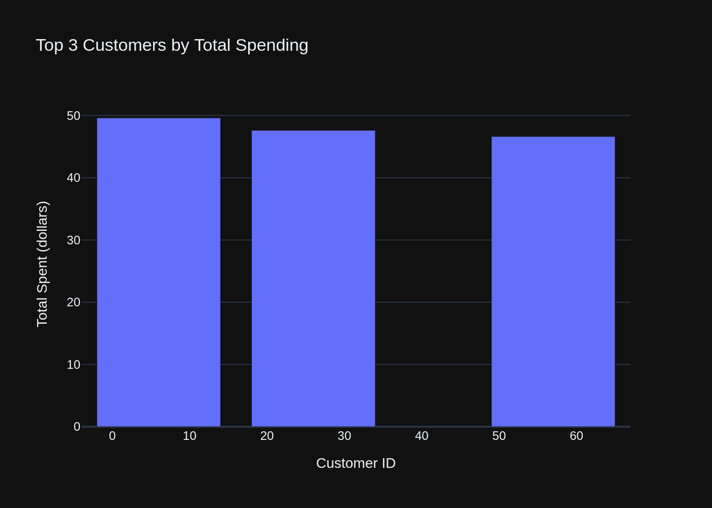

```
('SELECT CustomerId, SUM(Total) AS TotalSpent\nFROM Invoice\nGROUP BY CustomerId\nORDER BY TotalSpent DESC\nLIMIT 3',
    CustomerId  TotalSpent
 0           6       49.62
 1          26       47.62
 2          57       46.62,
 Figure({
     'data': [{'type': 'bar', 'x': array([ 6, 26, 57]), 'y': array([49.62, 47.62, 46.62])}],
     'layout': {'template': '...',
                'title': {'text': 'Top 3 Customers by Total Spending'},
                'xaxis': {'title': {'text': 'Customer ID'}},
                'yaxis': {'title': {'text': 'Total Spent (dollars)'}}}
 }))
```

```python
question = """
     Find the top 3 customers who spent the most money overall:
"""

vn.ask(question=question)
```

````
SQL Prompt: [{'role': 'system', 'content': "You are a SQLite expert. Please help to generate a SQL query to answer the question. Your response should ONLY be based on the given context and follow the response guidelines and format instructions. \n===Tables \nCREATE INDEX IFK_PlaylistTrackTrackId ON …
Info: Ollama parameters:
model=llama3.1:latest,
options={},
keep_alive=None
Info: Prompt Content:
[{"role": "system", "content": "You are a SQLite expert. Please help to generate a SQL query to answer the question. Your response should ONLY be based on the given context and follow the response guidelines and format instructions. \n===Tables \nCREATE INDEX IFK_PlaylistTrackTrackId ON PlaylistTrac…
Info: Ollama Response:
{'model': 'llama3.1:latest', 'created_at': '2024-07-24T05:43:23.619931224Z', 'message': {'role': 'assistant', 'content': 'SELECT P.Name, SUM(T.Milliseconds / 1000) AS TotalDuration\nFROM Playlist P \nJOIN PlaylistTrack PT ON P.PlaylistId = PT.PlaylistId \nJOIN Track T ON PT.TrackId = T.TrackId \nGRO…
LLM Response: SELECT P.Name, SUM(T.Milliseconds / 1000) AS TotalDuration
FROM Playlist P
JOIN PlaylistTrack PT ON P.PlaylistId = PT.PlaylistId
JOIN Track T ON PT.TrackId = T.TrackId
GROUP BY P.Name
HAVING COUNT(DISTINCT T.TrackId) >= 10
SELECT P.Name, SUM(T.Milliseconds / 1000) AS TotalDuration
FROM Playlist P
JOIN PlaylistTrack PT ON P.PlaylistId = PT.PlaylistId
JOIN Track T ON PT.TrackId = T.TrackId
GROUP BY P.Name
HAVING COUNT(DISTINCT T.TrackId) >= 10
                         Name  TotalDuration
0                  90’s Music         397970
1             Brazilian Music           9464
2                   Classical          21736
3   Classical 101 - Deep Cuts           6742
4  Classical 101 - Next Steps           7565
5  Classical 101 - The Basics           7429
6                      Grunge           4114
7         Heavy Metal Classic           8189
8                       Music        1752098
9                    TV Shows        1001974
Info: Ollama parameters:
model=llama3.1:latest,
options={},
keep_alive=None
Info: Prompt Content:
[{"role": "system", "content": "The following is a pandas DataFrame that contains the results of the query that answers the question the user asked: '  \n     Get all playlists containing at least 10 tracks and the total duration of those tracks:\n'\n\nThe DataFrame was produced using this query: SE…
Info: Ollama Response:
{'model': 'llama3.1:latest', 'created_at': '2024-07-24T05:43:39.712770325Z', 'message': {'role': 'assistant', 'content': "```python\nimport plotly.express as px\n\nfig = px.bar(df, x='Name', y='TotalDuration')\nfig.show()\n```"}, 'done_reason': 'stop', 'done': True, 'total_duration': 15958713633, 'l…
````

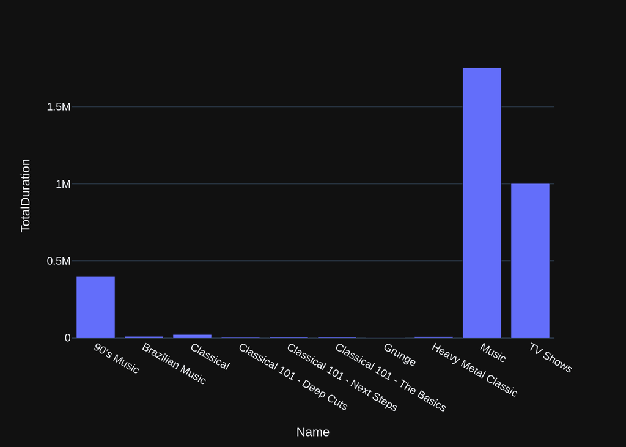

```
('SELECT P.Name, SUM(T.Milliseconds / 1000) AS TotalDuration\nFROM Playlist P \nJOIN PlaylistTrack PT ON P.PlaylistId = PT.PlaylistId \nJOIN Track T ON PT.TrackId = T.TrackId \nGROUP BY P.Name \nHAVING COUNT(DISTINCT T.TrackId) >= 10',
                          Name  TotalDuration
 0                  90’s Music         397970
 1             Brazilian Music           9464
 2                   Classical          21736
 3   Classical 101 - Deep Cuts           6742
 4  Classical 101 - Next Steps           7565
 5  Classical 101 - The Basics           7429
 6                      Grunge           4114
 7         Heavy Metal Classic           8189
 8                       Music        1752098
 9                    TV Shows        1001974,
 Figure({
     'data': [{'alignmentgroup': 'True',
               'hovertemplate': 'Name=%{x}<br>TotalDuration=%{y}<extra></extra>',
               'legendgroup': '',
               'marker': {'color': '#636efa', 'pattern': {'shape': ''}},
               'name': '',
               'offsetgroup': '',
               'orientation': 'v',
               'showlegend': False,
               'textposition': 'auto',
               'type': 'bar',
               'x': array(['90’s Music', 'Brazilian Music', 'Classical',
                           'Classical 101 - Deep Cuts', 'Classical 101 - Next Steps',
                           'Classical 101 - The Basics', 'Grunge', 'Heavy Metal Classic', 'Music',
                           'TV Shows'], dtype=object),
               'xaxis': 'x',
               'y': array([ 397970,    9464,   21736,    6742,    7565,    7429,    4114,    8189,
                           1752098, 1001974]),
               'yaxis': 'y'}],
     'layout': {'barmode': 'relative',
                'legend': {'tracegroupgap': 0},
                'margin': {'t': 60},
                'template': '...',
                'xaxis': {'anchor': 'y', 'domain': [0.0, 1.0], 'title': {'text': 'Name'}},
                'yaxis': {'anchor': 'x', 'domain': [0.0, 1.0], 'title': {'text': 'TotalDuration'}}}
 }))
```

```python
question = """
     Get all playlists containing at least 10 tracks and the total duration of those tracks:
"""

vn.ask(question=question)
```

````
SQL Prompt: [{'role': 'system', 'content': "You are a SQLite expert. Please help to generate a SQL query to answer the question. Your response should ONLY be based on the given context and follow the response guidelines and format instructions. \n===Tables \nCREATE INDEX IFK_AlbumArtistId ON Album (…
Info: Ollama parameters:
model=llama3.1:latest,
options={},
keep_alive=None
Info: Prompt Content:
[{"role": "system", "content": "You are a SQLite expert. Please help to generate a SQL query to answer the question. Your response should ONLY be based on the given context and follow the response guidelines and format instructions. \n===Tables \nCREATE INDEX IFK_AlbumArtistId ON Album (ArtistId)\n\…
Info: Ollama Response:
{'model': 'llama3.1:latest', 'created_at': '2024-07-24T05:44:52.501370299Z', 'message': {'role': 'assistant', 'content': 'SELECT A.Name, COUNT(DISTINCT T.GenreId) AS NumberOfGenres\nFROM Artist A\nJOIN Album AS ALBUM ON A.ArtistId = ALBUM.ArtistId\nJOIN Track T ON ALBUM.AlbumId = T.AlbumId\nGROUP BY…
LLM Response: SELECT A.Name, COUNT(DISTINCT T.GenreId) AS NumberOfGenres
FROM Artist A
JOIN Album AS ALBUM ON A.ArtistId = ALBUM.ArtistId
JOIN Track T ON ALBUM.AlbumId = T.AlbumId
GROUP BY A.Name
HAVING COUNT(DISTINCT T.GenreId) > 1
SELECT A.Name, COUNT(DISTINCT T.GenreId) AS NumberOfGenres
FROM Artist A
JOIN Album AS ALBUM ON A.ArtistId = ALBUM.ArtistId
JOIN Track T ON ALBUM.AlbumId = T.AlbumId
GROUP BY A.Name
HAVING COUNT(DISTINCT T.GenreId) > 1
                     Name  NumberOfGenres
0           Amy Winehouse               2
1    Antônio Carlos Jobim               2
2              Audioslave               3
3    Battlestar Galactica               3
4            Eric Clapton               2
5           Faith No More               2
6            Foo Fighters               2
7            Gilberto Gil               3
8           Guns N' Roses               2
9                  Heroes               2
10            Iron Maiden               4
11             Jamiroquai               3
12          Lenny Kravitz               3
13                   Lost               2
14          Ozzy Osbourne               2
15              Pearl Jam               2
16                 R.E.M.               2
17  Red Hot Chili Peppers               2
18             The Office               2
19                     U2               2
20        Various Artists               3
Info: Ollama parameters:
model=llama3.1:latest,
options={},
keep_alive=None
Info: Prompt Content:
[{"role": "system", "content": "The following is a pandas DataFrame that contains the results of the query that answers the question the user asked: '  \n     Identify artists who have albums with tracks appearing in multiple genres:\n'\n\nThe DataFrame was produced using this query: SELECT A.Name, …
Info: Ollama Response:
{'model': 'llama3.1:latest', 'created_at': '2024-07-24T05:45:17.205040957Z', 'message': {'role': 'assistant', 'content': '```python\nimport plotly.express as px\n\nfig = px.bar(df, x=\'Name\', y=\'NumberOfGenres\')\nif df[\'NumberOfGenres\'].nunique() == 1:\n    fig.update_layout(title_text=f\'Numbe…
````

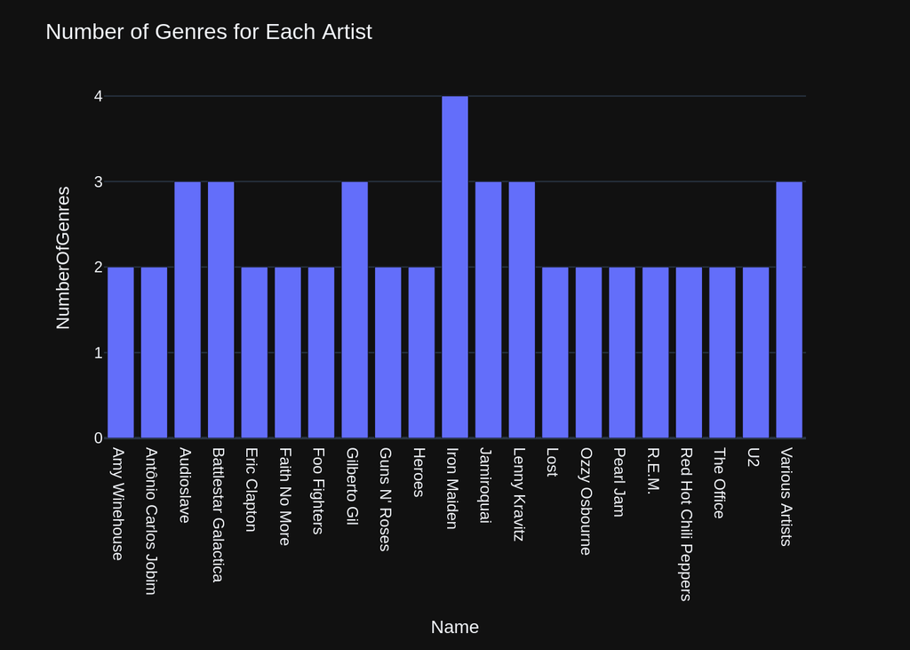

```
('SELECT A.Name, COUNT(DISTINCT T.GenreId) AS NumberOfGenres\nFROM Artist A\nJOIN Album AS ALBUM ON A.ArtistId = ALBUM.ArtistId\nJOIN Track T ON ALBUM.AlbumId = T.AlbumId\nGROUP BY A.Name\nHAVING COUNT(DISTINCT T.GenreId) > 1',
                      Name  NumberOfGenres
 0           Amy Winehouse               2
 1    Antônio Carlos Jobim               2
 2              Audioslave               3
 3    Battlestar Galactica               3
 4            Eric Clapton               2
 5           Faith No More               2
 6            Foo Fighters               2
 7            Gilberto Gil               3
 8           Guns N' Roses               2
 9                  Heroes               2
 10            Iron Maiden               4
 11             Jamiroquai               3
 12          Lenny Kravitz               3
 13                   Lost               2
 14          Ozzy Osbourne               2
 15              Pearl Jam               2
 16                 R.E.M.               2
 17  Red Hot Chili Peppers               2
 18             The Office               2
 19                     U2               2
 20        Various Artists               3,
 Figure({
     'data': [{'alignmentgroup': 'True',
               'hovertemplate': 'Name=%{x}<br>NumberOfGenres=%{y}<extra></extra>',
               'legendgroup': '',
               'marker': {'color': '#636efa', 'pattern': {'shape': ''}},
               'name': '',
               'offsetgroup': '',
               'orientation': 'v',
               'showlegend': False,
               'textposition': 'auto',
               'type': 'bar',
               'x': array(['Amy Winehouse', 'Antônio Carlos Jobim', 'Audioslave',
                           'Battlestar Galactica', 'Eric Clapton', 'Faith No More', 'Foo Fighters',
                           'Gilberto Gil', "Guns N' Roses", 'Heroes', 'Iron Maiden', 'Jamiroquai',
                           'Lenny Kravitz', 'Lost', 'Ozzy Osbourne', 'Pearl Jam', 'R.E.M.',
                           'Red Hot Chili Peppers', 'The Office', 'U2', 'Various Artists'],
                          dtype=object),
               'xaxis': 'x',
               'y': array([2, 2, 3, 3, 2, 2, 2, 3, 2, 2, 4, 3, 3, 2, 2, 2, 2, 2, 2, 2, 3]),
               'yaxis': 'y'}],
     'layout': {'barmode': 'relative',
                'legend': {'tracegroupgap': 0},
                'margin': {'t': 60},
                'template': '...',
                'title': {'text': 'Number of Genres for Each Artist'},
                'xaxis': {'anchor': 'y', 'domain': [0.0, 1.0], 'title': {'text': 'Name'}},
                'yaxis': {'anchor': 'x', 'domain': [0.0, 1.0], 'title': {'text': 'NumberOfGenres'}}}
 }))
```

```python
question = """
     Identify artists who have albums with tracks appearing in multiple genres:
"""

vn.ask(question=question)
```

### Check completion time

```python
ts_stop = time()

elapsed_time = ts_stop - ts_start
print(f"elapsed_time : {elapsed_time} sec")
```

```
elapsed_time : 1915.2621357440948 sec
```

## Launch the User Interface

[figure not shown]

## Next Steps

Using Vanna via Jupyter notebooks is great for getting started but check out additional customizable interfaces like the

- [Streamlit app](https://github.com/vanna-ai/vanna-streamlit)
- [Flask app](https://github.com/vanna-ai/vanna-flask)
- [Slackbot](https://github.com/vanna-ai/vanna-slack)